# Modeling and prediction for movies

### Load packages

```r
library(ggplot2)
library(dplyr)
library(statsr)
```

### Load data

```r
load("movies.Rdata")
```

## Part 1: Data

The dataset generated from a random sampling from IMDB movie list and Rotten Tomatoes which is given in the project details.The random assesment will help us in our model on the basis of randomness of the data.

## Part 2: Research question

From the given dataset we are interested in learning what attributes make a movie popular by fitting a Multiple Regression Model(MLR) with suitable explanatory variables and response variable from the dataset.we are also interested in prediction from the fitted MLR model for a movie,released after 2016.Also we are highly concerned in selecting proper explanatory variables from the 32 variables given in the dataset in order to omit collinearity and end up with a parsimonious model for better prediction.We are going to investigate those factors which are highly correlated to each other in order to omit them.

## Part 3: Exploratory data analysis

1. In order to omit the variables which are highly correlated to reduce the collinearity of the model we inspect the correlation coefficient and the scatterplot to make decision.
2. Then we finally select the explanatory variables which are significant to the model.
3. From data vizualization we can omit the 5 variables “actor1” to “actor5” as they are only used to determine whether the movie casts an actor or actress who won a best actor or actress Oscar.

d)Again the time series data columns “thtr_rel_year” to “dvd_rel_day” are irrelevant to predict whether the movie is popular or not or as a significant predictor and we can also omit them by just visualizing the dataset and days,months,year are highly correlated.

we are going to calculate correlation coeeficient of the remaining variables-

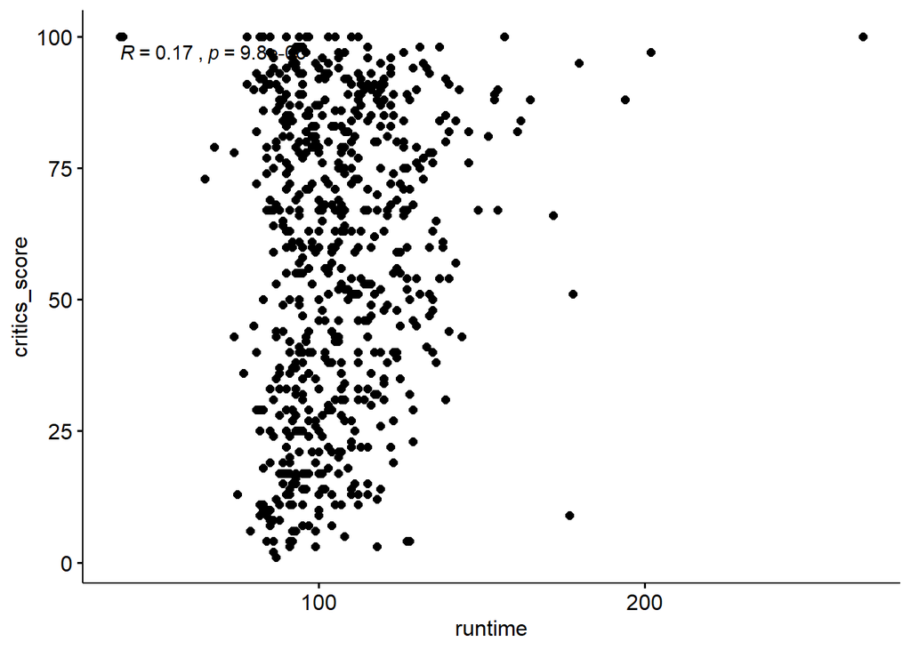

```r
library(ggpubr)
ggscatter(movies,x="runtime",y="critics_score",cor.coef=T,cor.method="pearson")
```

Note that the correlation between the variables is significantly low so we can use them in our modelling

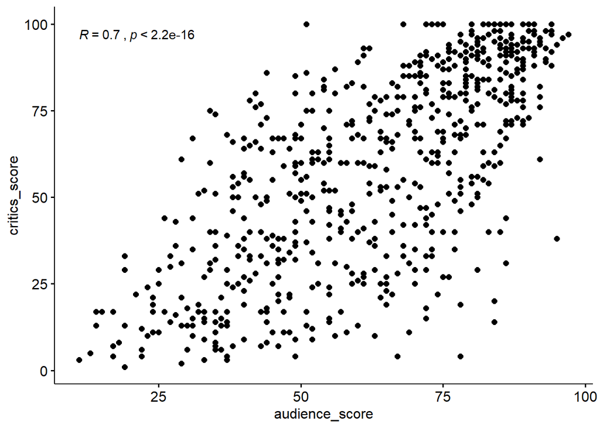

```r
ggscatter(movies,x="audience_score",y="critics_score",cor.coef=T,cor.method="pearson")
```

Note that we can see a high positive correlation between the variables so we can omit them to reduce collinearity of the model

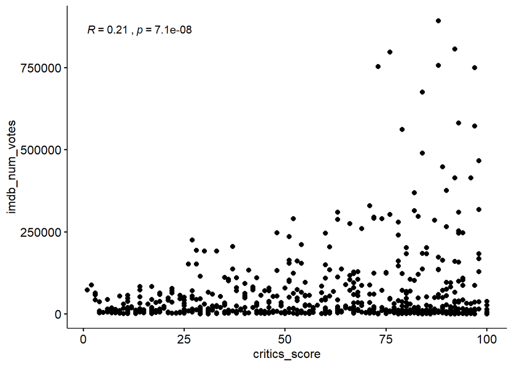

```r
ggscatter(movies,x="critics_score",y="imdb_num_votes",cor.coef=T,cor.method="pearson")
```

Note that the correlation between the variables is significantly low so we can use them in our modelling

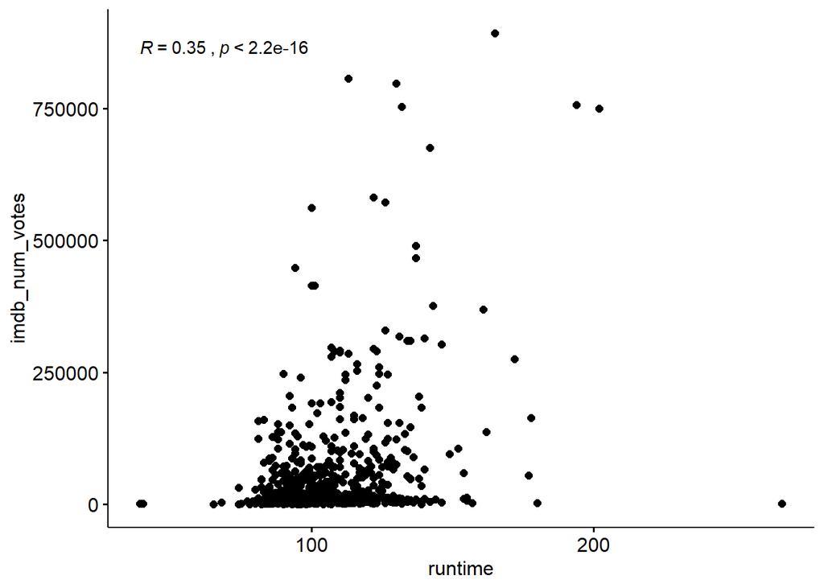

```r
ggscatter(movies,x="runtime",y="imdb_num_votes",cor.coef=T,cor.method="pearson")
```

From the graph and the correlation coefficient we can conclude that there is no problem with this two variable on the basis of collinearity

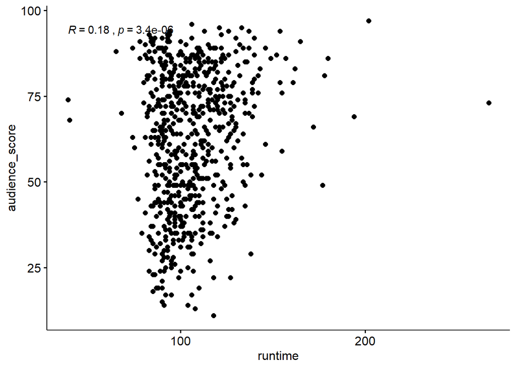

```r
ggscatter(movies,x="runtime",y="audience_score",cor.coef=T,cor.method="pearson")
```

The correlation coefficient is pretty low so we can include the variables in our modelling

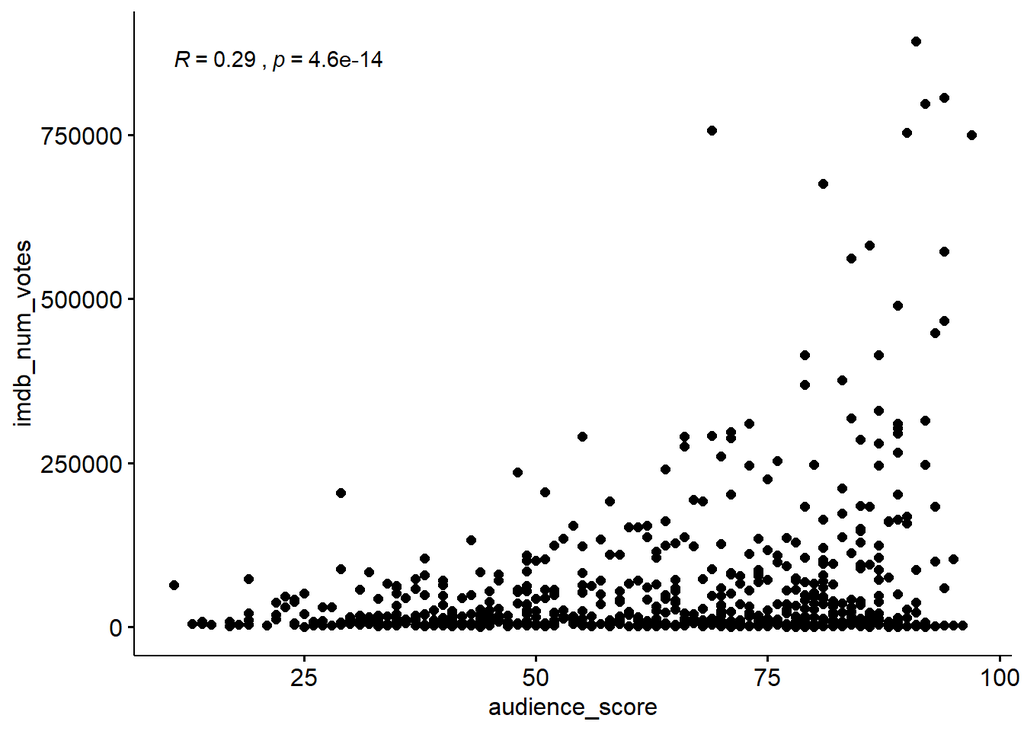

```r
ggscatter(movies,x="audience_score",y="imdb_num_votes",cor.coef=T,cor.method="pearson")
```

Again from the scatterplot and the correlation coefficient tell us there is no prblem with the collinearity.

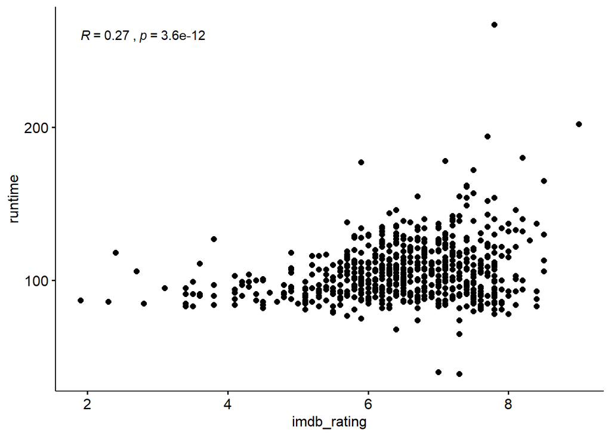

```r
ggscatter(movies,x="imdb_rating",y="runtime",cor.coef=T,cor.method="pearson")
```

There is pretty low correlation coefficient,so we have nothing to worry.

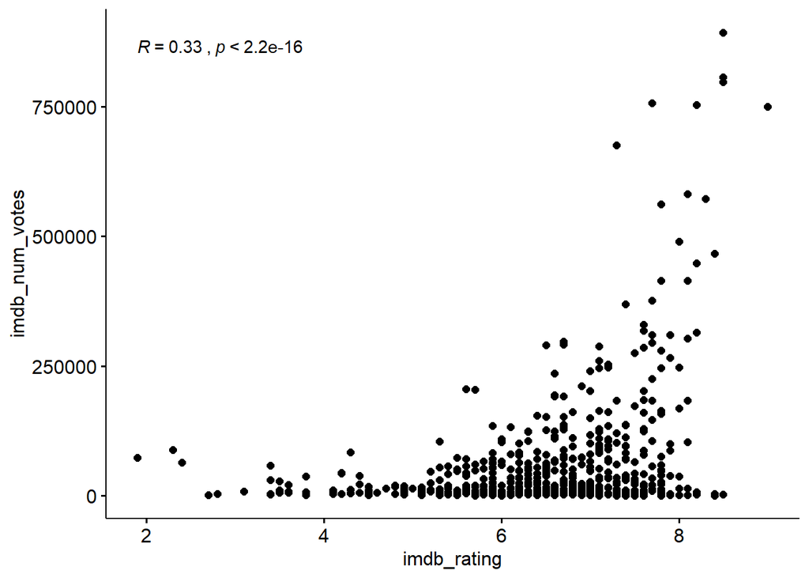

```r
ggscatter(movies,x="imdb_rating",y="imdb_num_votes",cor.coef=T,cor.method="pearson")
```

There is no problem at all in context of high correlation coefficient.

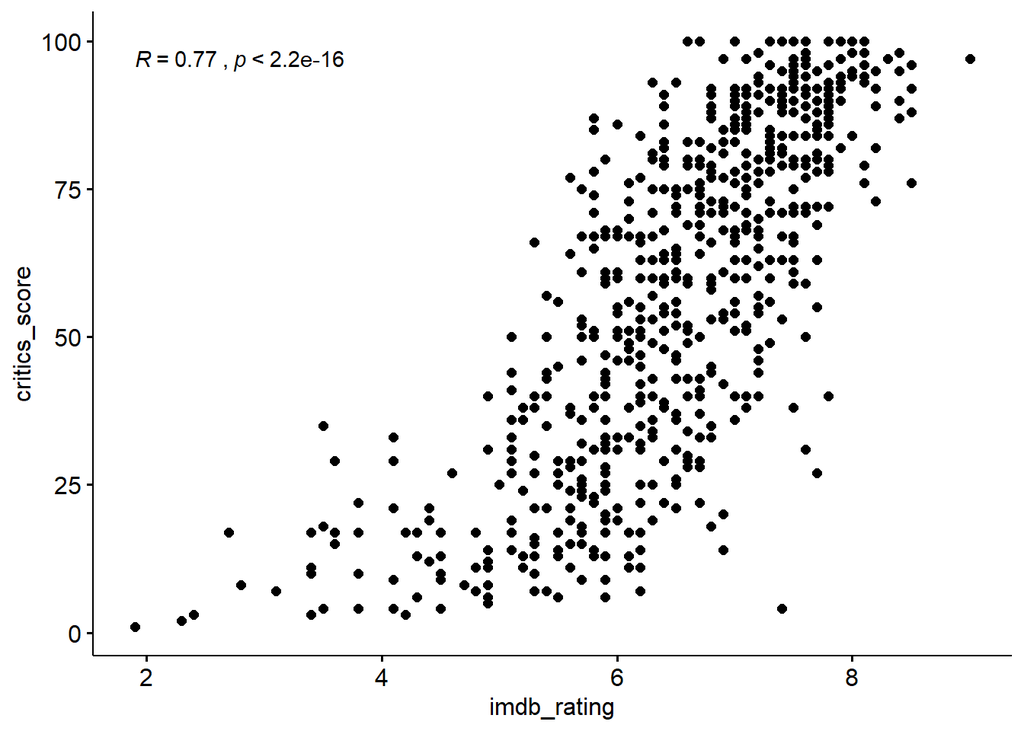

```r
ggscatter(movies,x="imdb_rating",y="critics_score",cor.coef=T,cor.method="pearson")
```

There is a problem in including the variables in the model as they are highly positively correlated

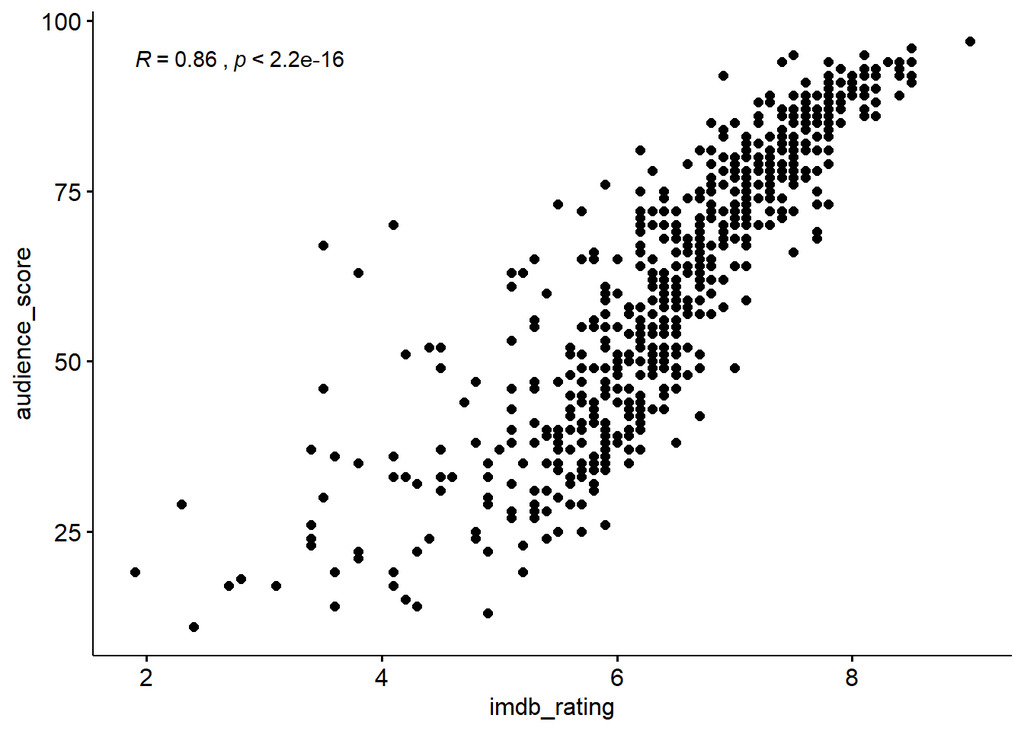

```r
ggscatter(movies,x="imdb_rating",y="audience_score",cor.coef=T,cor.method="pearson")
```

Again we found collinearity problem arising here as they are highly positively correlated

Finally we are here to conclude the explanatory variable and response variable on the basis of the previous study and sticking on the goal of fitting a parsimonious model-

The Explanatory Variables:

a)Title type(as the id of the film) b)Genre c)Runtime d)imdb rating e)imdb number of votes f) Top 200 box office g)Best picture nomination (as the outstanding source it can be bring new viewers)

The response variable : Audience score (as we are to predict what makes a movie famous among audience)

The matrix of scatterplots are now represented to summarise the correlation between the predictors in a single image

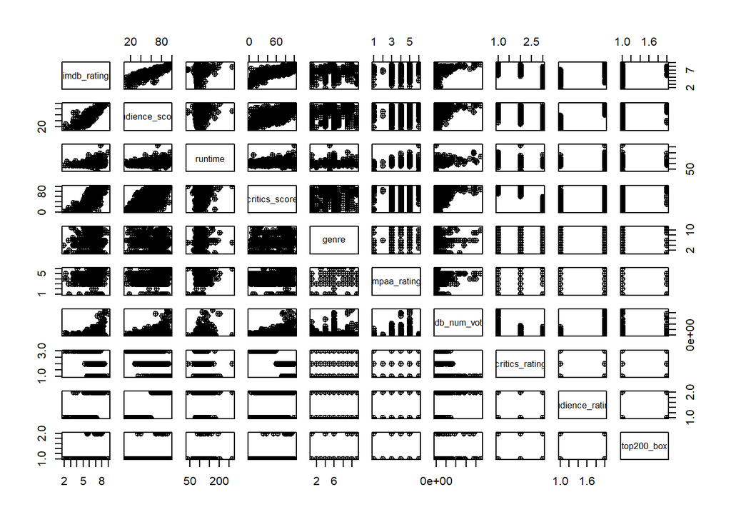

```r
pairs(~imdb_rating+audience_score+runtime+critics_score+genre+mpaa_rating+imdb_num_votes+
        critics_rating+audience_rating+top200_box,pch=10,data=movies)
```

## Part 4: Modeling

After selecting the explanatory variable and the response variable on the basis of reducing collinearity of the model and to get a parsimonious model,we are going to fit the required model.

```
        Now we are going to fit the MLR model with the 7 explantory variables(x) to predict the response variable(y) Audience score
```

```r
Reg_model<- lm(audience_score~title_type+genre+runtime+imdb_rating+imdb_num_votes+
                 top200_box+best_pic_nom,data = movies)
summary(Reg_model)
```

```
##
## Call:
## lm(formula = audience_score ~ title_type + genre + runtime +
##     imdb_rating + imdb_num_votes + top200_box + best_pic_nom,
##     data = movies)
##
## Residuals:
##     Min      1Q  Median      3Q     Max
## -27.372  -6.304   0.424   5.537  50.148
##
## Coefficients:
##                                  Estimate Std. Error t value Pr(>|t|)
## (Intercept)                    -3.595e+01  5.246e+00  -6.852 1.73e-11 ***
## title_typeFeature Film          2.327e-01  3.639e+00   0.064  0.94903
## title_typeTV Movie              1.441e+00  5.774e+00   0.250  0.80294
## genreAnimation                  9.031e+00  3.529e+00   2.559  0.01073 *
## genreArt House & International  2.392e-01  2.948e+00   0.081  0.93534
## genreComedy                     2.125e+00  1.635e+00   1.299  0.19427
## genreDocumentary                2.553e+00  3.909e+00   0.653  0.51388
## genreDrama                      7.026e-01  1.411e+00   0.498  0.61877
## genreHorror                    -4.975e+00  2.413e+00  -2.062  0.03964 *
## genreMusical & Performing Arts  6.180e+00  3.384e+00   1.826  0.06830 .
## genreMystery & Suspense        -5.595e+00  1.799e+00  -3.109  0.00196 **
## genreOther                      2.119e+00  2.791e+00   0.759  0.44796
## genreScience Fiction & Fantasy  2.820e-01  3.509e+00   0.080  0.93598
## runtime                        -5.955e-02  2.294e-02  -2.595  0.00967 **
## imdb_rating                     1.595e+01  4.574e-01  34.880  < 2e-16 ***
## imdb_num_votes                  3.327e-06  4.249e-06   0.783  0.43395
## top200_boxyes                   2.005e+00  2.718e+00   0.738  0.46098
## best_pic_nomyes                 3.987e+00  2.322e+00   1.717  0.08651 .
## ---
## Signif. codes:  0 '***' 0.001 '**' 0.01 '*' 0.05 '.' 0.1 ' ' 1
##
## Residual standard error: 9.858 on 632 degrees of freedom
##   (1 observation deleted due to missingness)
## Multiple R-squared:  0.7689, Adjusted R-squared:  0.7627
## F-statistic: 123.7 on 17 and 632 DF,  p-value: < 2.2e-16
```

Inference of the MLR: Start with a simple test that examine whether the model is significant as a whole or not by a suitable F-test

Hypothesis:

Null hypothesis : All the slopes are qual to zero that is all the factors(explanatory variables) are insignificant Alternative hypothesis: At least one of the slope is non zero that is at least one of the factor is signifact

conclusion: From the F-statistic and the very low p-value(< 2.2e-16) we can conclude that we can reject null hypothesis,the model is significant as a whole but it does not imply each of the factors are significant.

Checking significance for each of the factors:

title_type : The p-values associated with title_type(with both levels) are significantly high so we can conclude title_type is insignificant for the model

genre : The p-values associated with genre(for all the 11 levels) are not all significantly high so we can not reject the categorical factor as a whole

runtime: The p-value associated with runtime is pretty low so it is a significant predictor of the audience_score

imdb_rating: The p-value associated with imdb_rating is very low with respect to the level of significance 0.05 that is imdb_rating is significant predictor for the MLR model

imdb_num_votes: The p-value associated with imdb_num_votes is quite high with respect to 0.05 so we can exclude it

top200_box: The p-value associated with top200_box is quite high with respect to 0.05 so it can also be excluded

best_pic_nom: it can also be excluded on the basis of p-value

The final full model can be written as after excluding the insignificant predictiors from the model -

```r
Reg_model_final<- lm(audience_score~genre+runtime+imdb_rating,data = movies)
summary(Reg_model_final)
```

```
##
## Call:
## lm(formula = audience_score ~ genre + runtime + imdb_rating,
##     data = movies)
##
## Residuals:
##     Min      1Q  Median      3Q     Max
## -27.404  -6.135   0.740   5.409  50.708
##
## Coefficients:
##                                 Estimate Std. Error t value Pr(>|t|)
## (Intercept)                    -38.54338    3.17207 -12.151  < 2e-16 ***
## genreAnimation                   9.05792    3.52529   2.569  0.01041 *
## genreArt House & International  -0.31822    2.91902  -0.109  0.91322
## genreComedy                      2.08204    1.62420   1.282  0.20035
## genreDocumentary                 1.53778    1.99560   0.771  0.44124
## genreDrama                       0.46079    1.37925   0.334  0.73842
## genreHorror                     -5.07663    2.40531  -2.111  0.03520 *
## genreMusical & Performing Arts   5.23078    3.14580   1.663  0.09685 .
## genreMystery & Suspense         -5.81702    1.78719  -3.255  0.00119 **
## genreOther                       2.50389    2.76651   0.905  0.36577
## genreScience Fiction & Fantasy   0.47490    3.50846   0.135  0.89237
## runtime                         -0.04537    0.02193  -2.069  0.03896 *
## imdb_rating                     16.25199    0.41954  38.738  < 2e-16 ***
## ---
## Signif. codes:  0 '***' 0.001 '**' 0.01 '*' 0.05 '.' 0.1 ' ' 1
##
## Residual standard error: 9.861 on 637 degrees of freedom
##   (1 observation deleted due to missingness)
## Multiple R-squared:  0.7669, Adjusted R-squared:  0.7625
## F-statistic: 174.6 on 12 and 637 DF,  p-value: < 2.2e-16
```

The way to get best fitted model using backward elimination method by adjusted R2:

Eliminating genre:

```r
Reg_model1<- lm(audience_score~runtime+imdb_rating,data = movies)
summary(Reg_model1)
```

```
##
## Call:
## lm(formula = audience_score ~ runtime + imdb_rating, data = movies)
##
## Residuals:
##     Min      1Q  Median      3Q     Max
## -27.147  -6.366   0.788   5.400  52.887
##
## Coefficients:
##              Estimate Std. Error t value Pr(>|t|)
## (Intercept) -38.10470    2.88154  -13.22  < 2e-16 ***
## runtime      -0.05723    0.02120   -2.70  0.00711 **
## imdb_rating  16.40731    0.37992   43.19  < 2e-16 ***
## ---
## Signif. codes:  0 '***' 0.001 '**' 0.01 '*' 0.05 '.' 0.1 ' ' 1
##
## Residual standard error: 10.12 on 647 degrees of freedom
##   (1 observation deleted due to missingness)
## Multiple R-squared:  0.7509, Adjusted R-squared:  0.7501
## F-statistic:   975 on 2 and 647 DF,  p-value: < 2.2e-16
```

Eliminating runtime:

```r
Reg_model2<- lm(audience_score~genre+imdb_rating,data = movies)
summary(Reg_model2)
```

```
##
## Call:
## lm(formula = audience_score ~ genre + imdb_rating, data = movies)
##
## Residuals:
##     Min      1Q  Median      3Q     Max
## -26.946  -6.195   0.627   5.615  50.488
##
## Coefficients:
##                                Estimate Std. Error t value Pr(>|t|)
## (Intercept)                    -41.9520     2.7207 -15.419  < 2e-16 ***
## genreAnimation                   9.7946     3.5155   2.786 0.005493 **
## genreArt House & International  -0.1029     2.9240  -0.035 0.971940
## genreComedy                      2.3439     1.6231   1.444 0.149197
## genreDocumentary                 2.0711     1.9615   1.056 0.291422
## genreDrama                       0.2961     1.3802   0.215 0.830196
## genreHorror                     -4.5930     2.3996  -1.914 0.056058 .
## genreMusical & Performing Arts   5.0689     3.1523   1.608 0.108326
## genreMystery & Suspense         -5.9951     1.7893  -3.350 0.000854 ***
## genreOther                       2.3126     2.7715   0.834 0.404357
## genreScience Fiction & Fantasy   0.5551     3.5165   0.158 0.874631
## imdb_rating                     16.0342     0.4068  39.416  < 2e-16 ***
## ---
## Signif. codes:  0 '***' 0.001 '**' 0.01 '*' 0.05 '.' 0.1 ' ' 1
##
## Residual standard error: 9.884 on 639 degrees of freedom
## Multiple R-squared:  0.7651, Adjusted R-squared:  0.7611
## F-statistic: 189.3 on 11 and 639 DF,  p-value: < 2.2e-16
```

Eliminating imdb_rating :

```r
Reg_model3<- lm(audience_score~genre+runtime,data = movies)
summary(Reg_model3)
```

```
##
## Call:
## lm(formula = audience_score ~ genre + runtime, data = movies)
##
## Residuals:
##     Min      1Q  Median      3Q     Max
## -51.871 -12.979   1.016  13.246  41.164
##
## Coefficients:
##                                Estimate Std. Error t value Pr(>|t|)
## (Intercept)                    36.15240    4.61039   7.842 1.88e-14 ***
## genreAnimation                 11.47585    6.45184   1.779   0.0758 .
## genreArt House & International 10.49688    5.31861   1.974   0.0489 *
## genreComedy                    -0.11401    2.97119  -0.038   0.9694
## genreDocumentary               30.41786    3.38836   8.977  < 2e-16 ***
## genreDrama                     10.37330    2.48080   4.181 3.30e-05 ***
## genreHorror                    -5.97625    4.40257  -1.357   0.1751
## genreMusical & Performing Arts 24.69187    5.68430   4.344 1.63e-05 ***
## genreMystery & Suspense         1.08257    3.25506   0.333   0.7396
## genreOther                     11.64799    5.04548   2.309   0.0213 *
## genreScience Fiction & Fantasy -2.42010    6.42057  -0.377   0.7064
## runtime                         0.16987    0.03883   4.375 1.42e-05 ***
## ---
## Signif. codes:  0 '***' 0.001 '**' 0.01 '*' 0.05 '.' 0.1 ' ' 1
##
## Residual standard error: 18.05 on 638 degrees of freedom
##   (1 observation deleted due to missingness)
## Multiple R-squared:  0.2178, Adjusted R-squared:  0.2043
## F-statistic: 16.15 on 11 and 638 DF,  p-value: < 2.2e-16
```

Conclusion:

Using backward elimination method we can not find smaller or more parsimonious model as there are no such increase in adjusted R2 in any of those three cases.The final model is-

[audience_score ~ genre + runtime + imdb_rating] where adjuste R2 is 76.25 that is 76% of the total varability can be explained by the final model.

Diagnostics for the MLR model:

In this part we are going to investigate the conditions for the multiple regression model(MLR)

a)Linear relationship between explanatory variables(numerical) and response variable

b)Nearly normal residuals

c)constant variability of residuals

d)Independence of residuals

Linear relationship between explanatory variables(numerical) and response variable:

we are going to plot residuals vs x and looking for a random scatter around zero.The two numerical explanatory variables are runtime and imdb_rating.

residuals vs runtime:

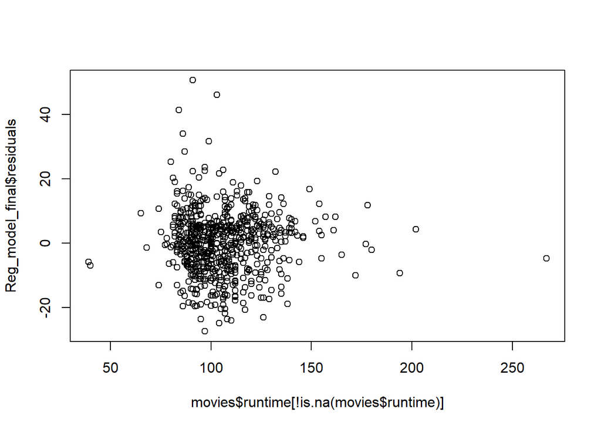

```r
plot(Reg_model_final$residuals~movies$runtime[!is.na(movies$runtime)])
```

```r
length(Reg_model_final$residuals)<-650
```

Note that there is a random scatter in the plot residuals vs runtime around zero so we can conclude that they are linearly related

Nearly normal residuals:

we can check the condition by plotting histogram and residual plot-

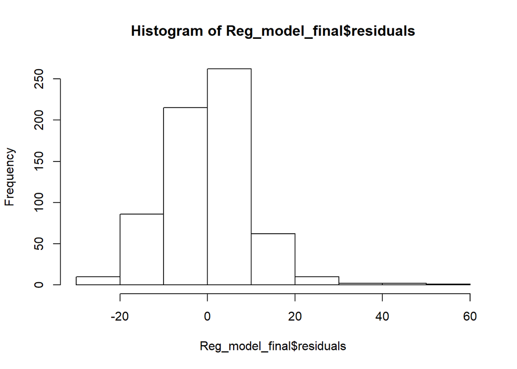

```r
hist(Reg_model_final$residuals)
```

The shape of the residual curve is fairly bell shaped and symmetric and symmetric around zero with a slightly large tail on the right side.

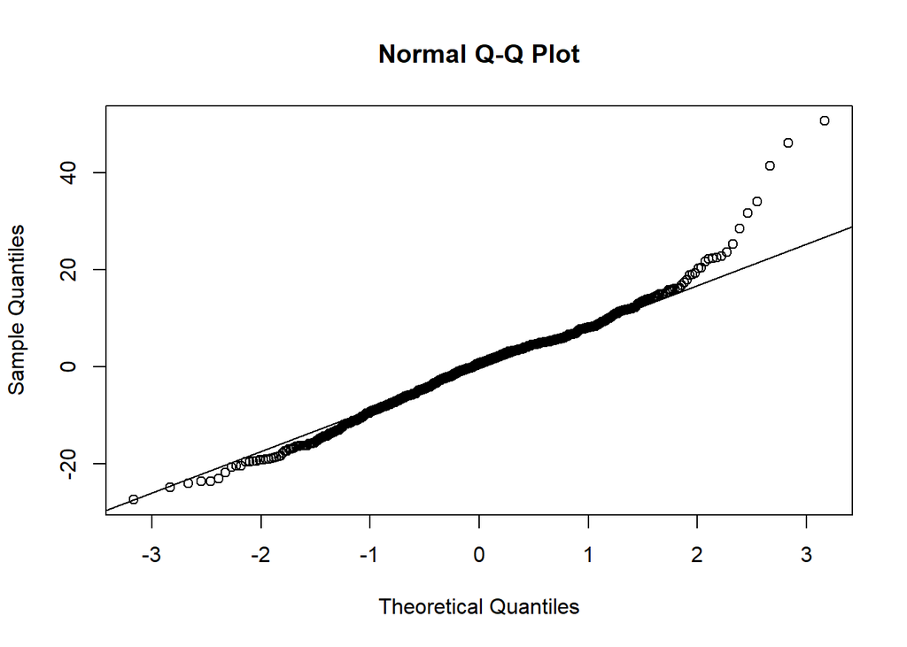

```r
qqnorm(Reg_model_final$residuals)
qqline(Reg_model_final$residuals)
```

This residual plot shows that inspite of having some outliers the residuals are fairly normal represented by the line in the plot.we can assume normality of the residuals.

constant variability of residuals:

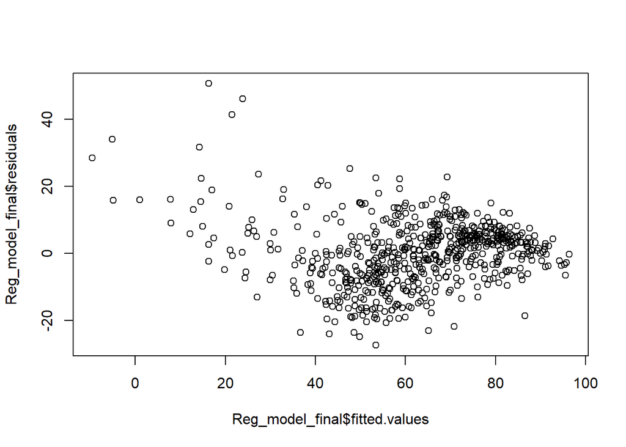

```r
plot(Reg_model_final$residuals~Reg_model_final$fitted.values)
```

we see that random scatter around zero and not any fan shape distribution with some outliers (at <20) but we can say that it shows fairly constant variability of the residuals.

Independence of residuals:

In this case we have no need to draw any plot as the sample size is >30 the samples are fairly normally distributed and as the data are randomly sampled it is quite obvious that the residuals are independent.

## Part 5: Prediction

we have to predict audience_score by the fitted model for a new movie released after 2016 that is not in the dataset.I’m interested in “Creed2” movie released in the year of 2018 with imdb_rating=7.1,runtime= 130 min and genre=drama.

```r
imdb_rating<-7.1
runtime<-130
genre<-"Drama"
new.data<-data.frame(imdb_rating,runtime,genre)
predict(Reg_model_final,newdata = new.data,interval = "prediction")
```

```
##        fit      lwr      upr
## 1 71.40908 51.99654 90.82163
```

reference of the movie: IMDB,Google

interpretation: The 95% prediction intervals associated with the new.data is (51.99,90.82). This means that, according to our model, 95% of the movies with such imdb_rating,runtime and genre have a audience_score between 51.99 and 90.82.

## Part 6: Conclusion

The multiple regression model is a well fitted model as 76% of the variability can be explained by the model.On the other hand the prediction we made satisfy the 95% confidence interval.The important point we can make from the analysis is that genre,runtime and imdb rating are the most important factors in predicting the popularity of a movie among public.